# Test 5, вариант 11. Черкасов Владислав, группа 520

```r
origin <- na.omit(read.csv("data_11.txt", sep = "\t", header = TRUE))
```

Загружаем данные, переходя к ряду из приростов цен. Его стационарность проверим тестом Дики-Фуллера:

```r
data <- origin[-1,]
data$Price <- diff(origin$Price)
data$Date <- origin$Date[-1]
library(stats)
data <- ts(data[,2], start = c(1994,1), frequency = 52)
new_data <- window(data, start = c(2009,25), end = c(2014,36))
library(tseries)
adf.test(new_data, k=52)
```

```
##
##  Augmented Dickey-Fuller Test
##
## data:  new_data
## Dickey-Fuller = -3.4718, Lag order = 52, p-value = 0.0459
## alternative hypothesis: stationary
```

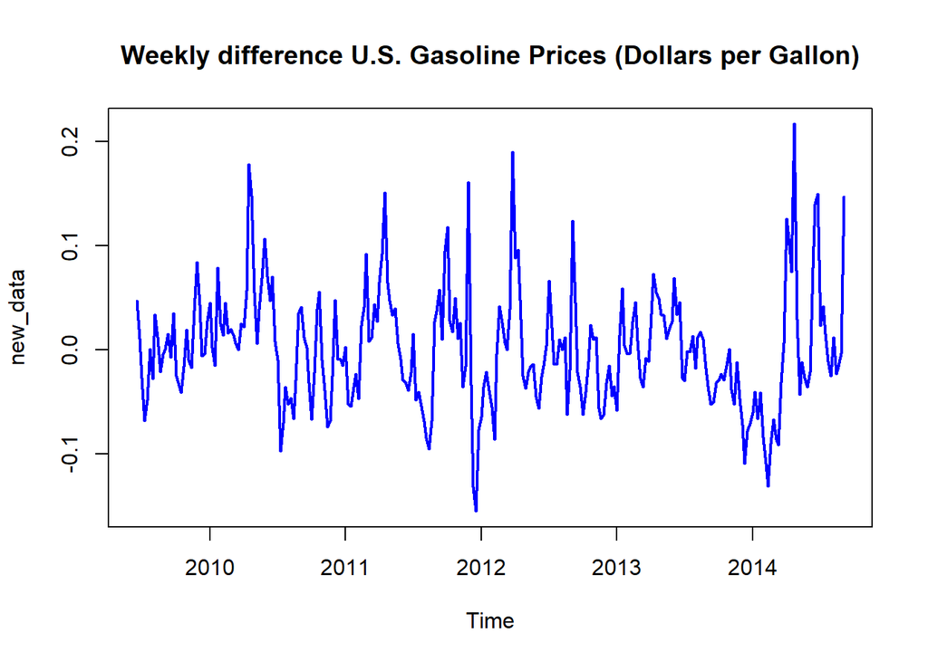

```r
plot(new_data ,type = "l", col = "blue",lwd = 2,main = "Weekly difference U.S. Gasoline Prices (Dollars per Gallon)")
```

Итак, полученный ряд можно считать стационарным в плане среднего значения. Пришлось немного отступить от исходных временных границ, чтобы добиться честной стационарности с точки зрения статистического теста, поскольку исходный промежуток времени был неидеален:

```r
adf.test(window(data, start = c(2010,1), end = c(2015,1)), k=52)
```

```
##
##  Augmented Dickey-Fuller Test
##
## data:  window(data, start = c(2010, 1), end = c(2015, 1))
## Dickey-Fuller = -3.0971, Lag order = 52, p-value = 0.1139
## alternative hypothesis: stationary
```

Построим графики ACF и PACF:

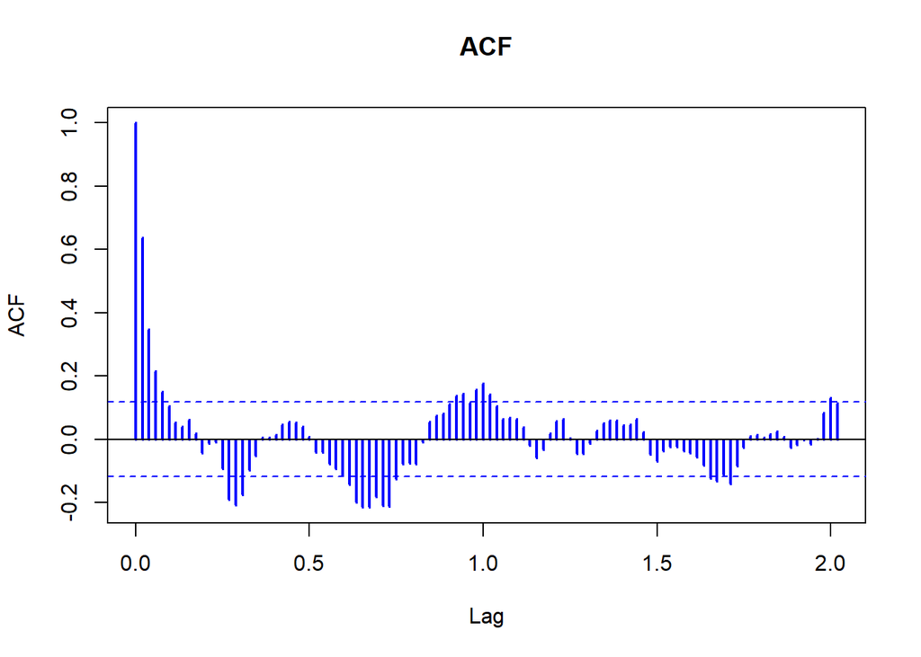

```r
acf(new_data, lwd = 2,main = "ACF",col = "blue",lag.max = 105)
```

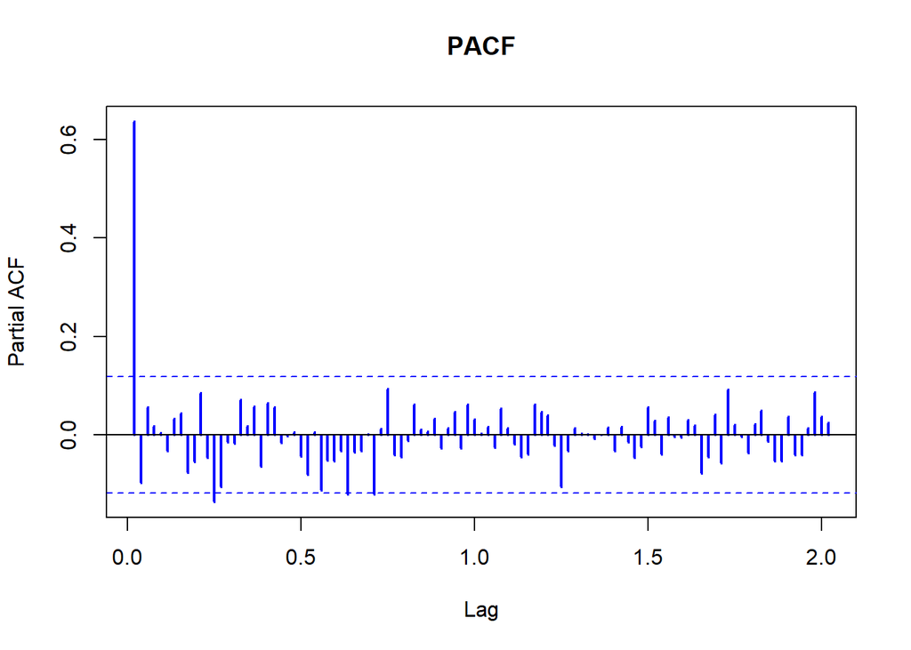

```r
pacf(new_data,lwd = 2,main = "PACF",col = "blue",lag.max=105)
```

График ACF обладает очень низкой скоростью затухания и большим количеством выбросов, поэтому требуется ориентироваться на график PACF, следовательно, будем считать, что данный временной ряд лучше описывать с помощью модели авторегрессии. Основываясь на этом графике, можно оценить порядок модели, как (1,0,0) с периодом сезонности 52, поскольку в году 52 недели. Проявления годовой сезонности не наблюдается, поэтому оставим сезонную компоненту нулевой. Для сравнения используем модель, которую предлагает функция автоматического подбора модели:

```r
library(forecast)
auto.arima(new_data)
```

```
## Series: new_data
## ARIMA(1,0,1)(0,0,1)[52] with zero mean
##
## Coefficients:
##          ar1     ma1    sma1
##       0.5234  0.2123  0.1001
## s.e.  0.0814  0.0948  0.0632
##
## sigma^2 = 0.0018:  log likelihood = 474.5
## AIC=-941   AICc=-940.85   BIC=-926.58
```

Оценим эти модели:

```r
library("lmtest")
arima_model <- arima(new_data,order = c(1,0,0),seasonal = list(order= c(0,0,0),period = 52),method = "ML")
coeftest(arima_model)
```

```
##
## z test of coefficients:
##
##            Estimate Std. Error z value Pr(>|z|)
## ar1       0.6524326  0.0466891 13.9740   <2e-16 ***
## intercept 0.0021792  0.0074190  0.2937    0.769
## ---
## Signif. codes:  0 '***' 0.001 '**' 0.01 '*' 0.05 '.' 0.1 ' ' 1
```

```r
AIC(arima_model)
```

```
## [1] -935.9264
```

```r
resid <- arima_model$residuals
Box.test(resid, lag = 52, type = "Ljung-Box", fitdf = 2)
```

```
##
##  Box-Ljung test
##
## data:  resid
## X-squared = 59.714, df = 50, p-value = 0.1634
```

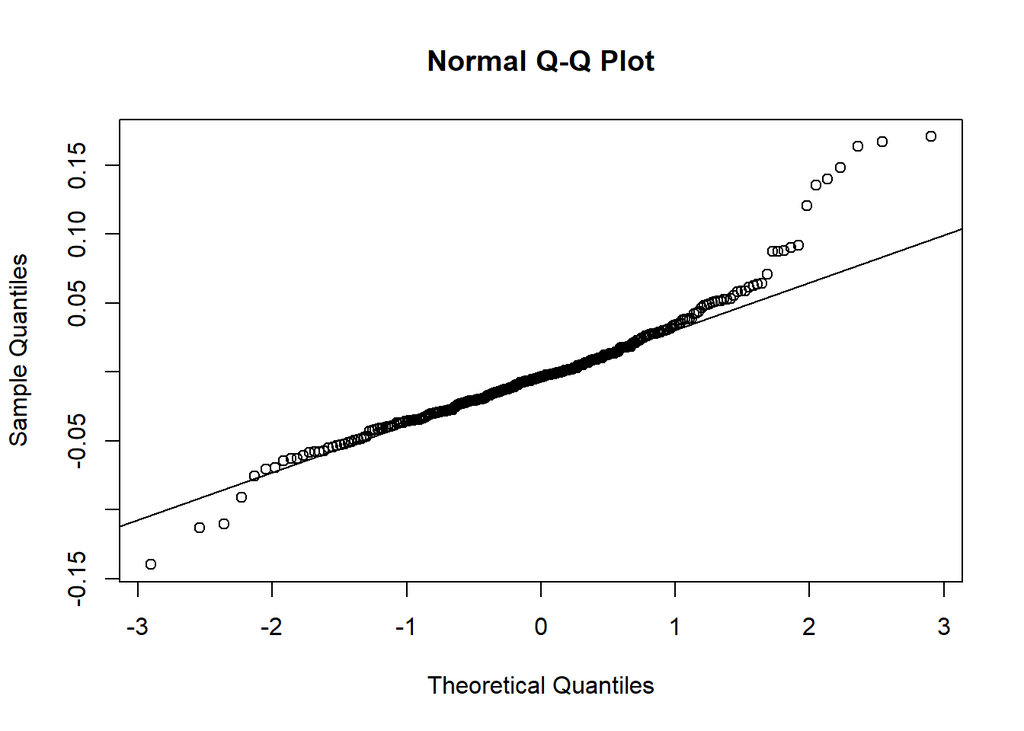

```r
qqnorm(resid)
qqline(resid)
```

```r
shapiro.test(resid)
```

```
##
##  Shapiro-Wilk normality test
##
## data:  resid
## W = 0.93744, p-value = 2.488e-09
```

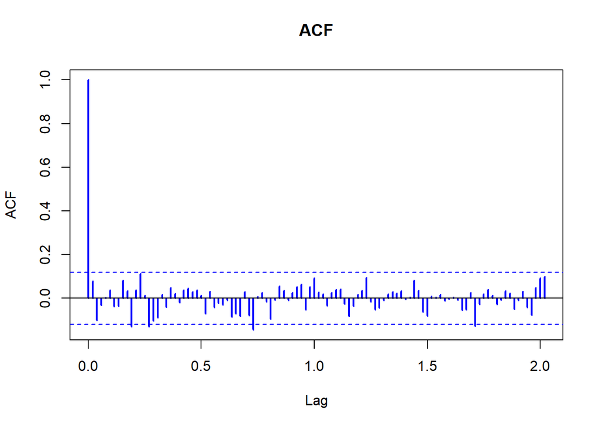

```r
acf(resid, lwd = 2,main = "ACF",col = "blue",lag.max=105)
```

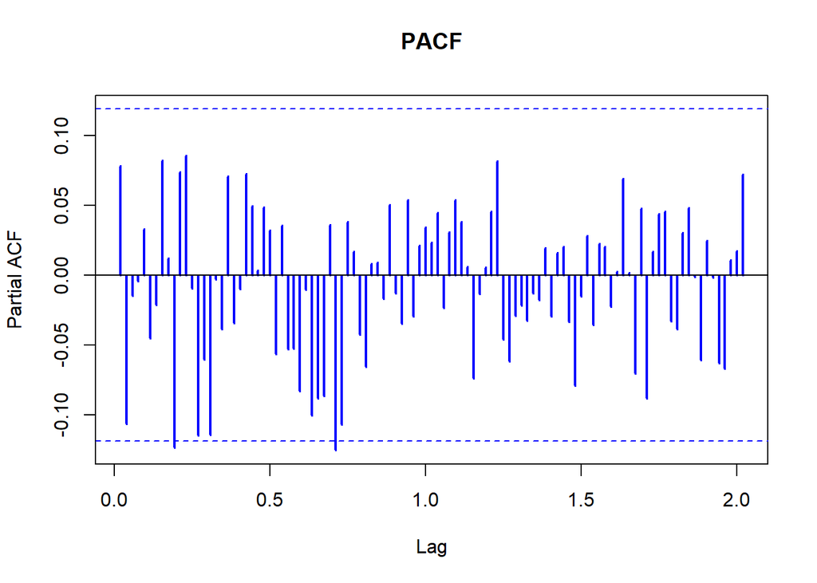

```r
pacf(resid, lwd = 2,main = "PACF",col = "blue",lag.max=105)
```

Остатки не похожи на нормально распределённые, как минимум, правый хвост довольно тяжёлый, автокорреляций в остатках не наблюдается. Сравним с другой моделью:

```r
arima_model <- arima(new_data,order = c(1,0,1),seasonal = list(order= c(0,0,1),period = 52),method = "ML")
coeftest(arima_model)
```

```
##
## z test of coefficients:
##
##            Estimate Std. Error z value  Pr(>|z|)
## ar1       0.5232482  0.0814180  6.4267 1.304e-10 ***
## ma1       0.2124464  0.0947961  2.2411   0.02502 *
## sma1      0.1001700  0.0631464  1.5863   0.11267
## intercept 0.0020979  0.0070085  0.2993   0.76468
## ---
## Signif. codes:  0 '***' 0.001 '**' 0.01 '*' 0.05 '.' 0.1 ' ' 1
```

```r
AIC(arima_model)
```

```
## [1] -939.0921
```

```r
resid <- arima_model$residuals
Box.test(resid, lag = 52, type = "Ljung-Box", fitdf = 2)
```

```
##
##  Box-Ljung test
##
## data:  resid
## X-squared = 50.406, df = 50, p-value = 0.4573
```

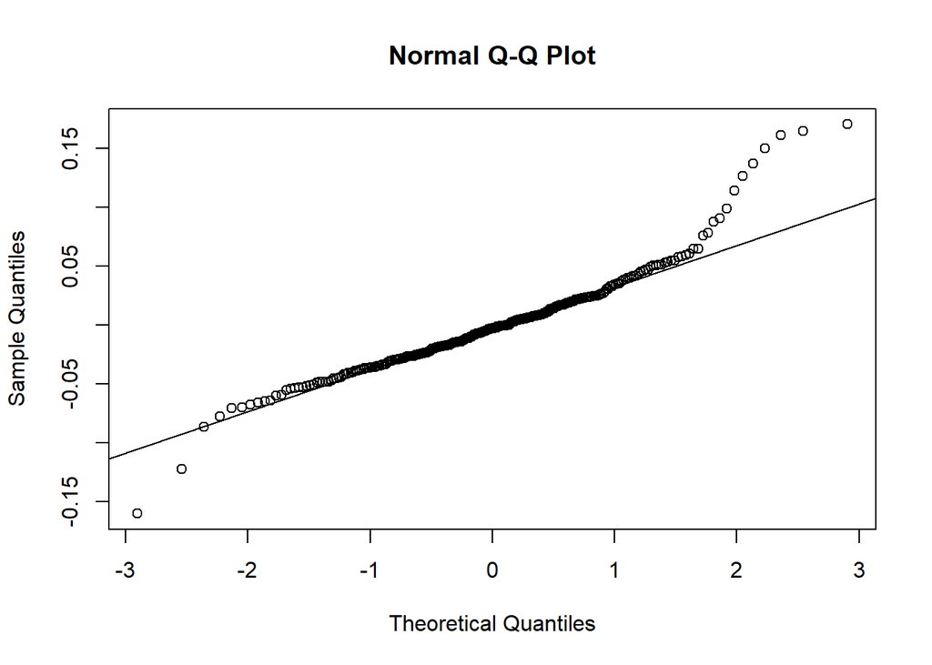

```r
qqnorm(resid)
qqline(resid)
```

```r
shapiro.test(resid)
```

```
##
##  Shapiro-Wilk normality test
##
## data:  resid
## W = 0.9372, p-value = 2.354e-09
```

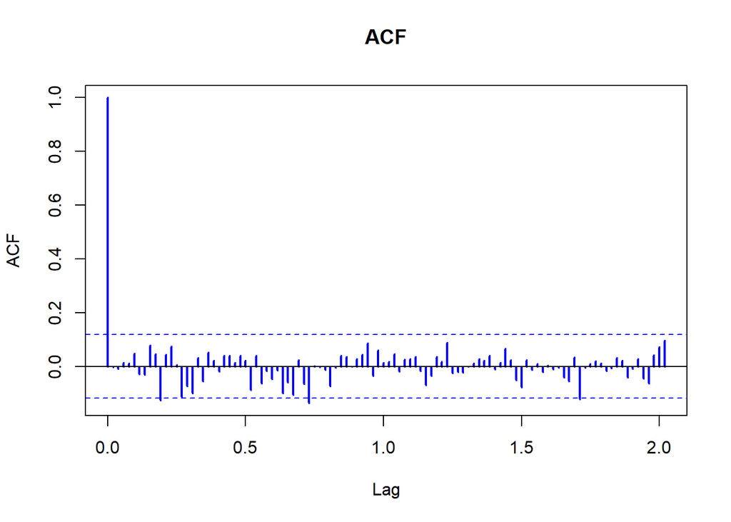

```r
acf(resid, lwd = 2,main = "ACF",col = "blue",lag.max=105)
```

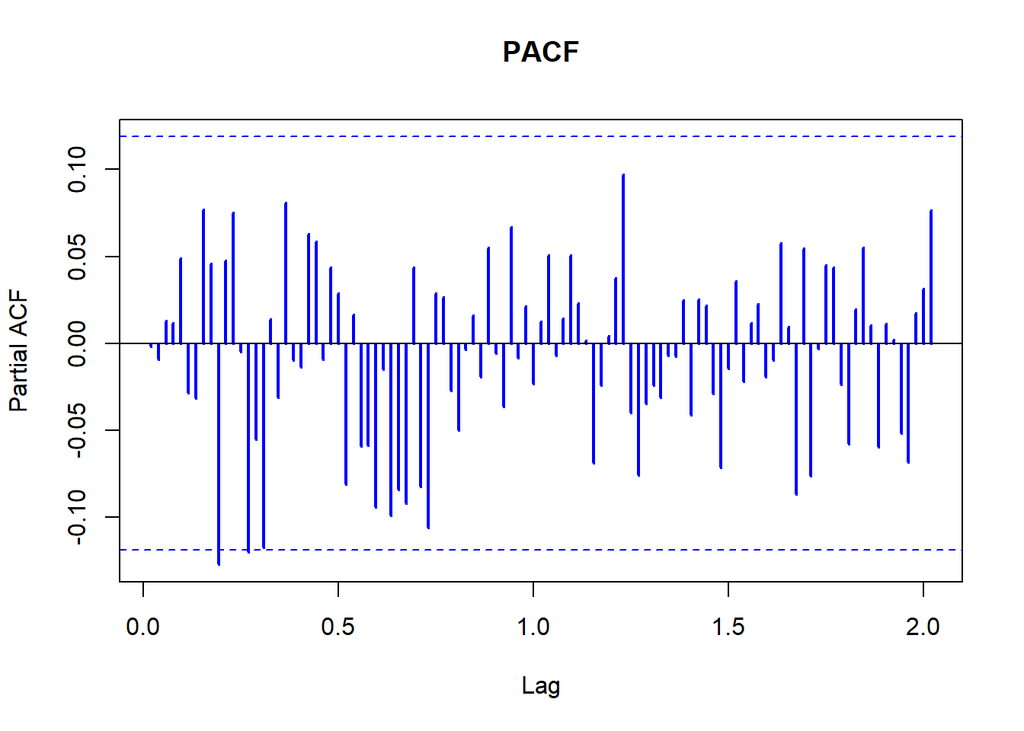

```r
pacf(resid, lwd = 2,main = "PACF",col = "blue",lag.max=105)
```

```r
arima_model <- arima(new_data,order = c(1,0,1),seasonal = list(order= c(0,0,0),period = 52),method = "ML")
coeftest(arima_model)
```

```
##
## z test of coefficients:
##
##            Estimate Std. Error z value  Pr(>|z|)
## ar1       0.5315255  0.0800974  6.6360 3.223e-11 ***
## ma1       0.2141277  0.0945167  2.2655   0.02348 *
## intercept 0.0019629  0.0066380  0.2957   0.76745
## ---
## Signif. codes:  0 '***' 0.001 '**' 0.01 '*' 0.05 '.' 0.1 ' ' 1
```

```r
AIC(arima_model)
```

```
## [1] -938.6259
```

```r
resid <- arima_model$residuals
Box.test(resid, lag = 52, type = "Ljung-Box", fitdf = 2)
```

```
##
##  Box-Ljung test
##
## data:  resid
## X-squared = 55.865, df = 50, p-value = 0.264
```